# COVID-19 BCR Repertoire Analysis

Deep sequencing of B cell receptor heavy chains in mild and severe COVID-19 patients

Author

Will Gammerdinger

Published

March 14, 2026

## 1 Background

Severe COVID-19 disease triggers a rapid and potent antibody response, yet the cellular and molecular determinants of protective versus pathological immunity remain incompletely understood. B cell receptor (BCR) sequencing provides a window into this response at single-sequence resolution, capturing the clonal structure, antigen-binding diversity, and isotype landscape of the antibody repertoire.

This report analyses a subset of the dataset published by **Galson et al. (2020)** (Galson et al. 2020), who performed deep BCR sequencing of peripheral blood mononuclear cells (PBMCs) from hospitalised COVID-19 patients at St Bartholomew’s Hospital, London. We focus on six patients — three with mild/moderate disease (no ICU admission) and three with severe/critical disease (ICU admission or intubation) — sequenced with the NEBNext Immune Sequencing Kit targeting the IgG heavy chain (IGH) locus.

> **Note:** Patient COV_S03 (SRR11961719) was excluded from clonal and repertoire-comparison analyses because all 21 productive sequences had quality-masked CDR3 junctions (N-characters introduced by pRESTO’s quality-based masking). These sequences cannot be reliably assigned to clones, so this sample is retained only in the sequence processing summary.

## 2 Data & Methods

### 2.1 Dataset

† Excluded from repertoire analysis: all CDR3 junctions quality-masked.

| Patient | SRR | Severity | Sex | Age |
| --- | --- | --- | --- | --- |
| COV_M01 | SRR11961714 | Mild | M | 39.0 |
| COV_M02 | SRR11961723 | Mild | M | 49.4 |
| COV_M03 | SRR11961727 | Mild | M | 39.6 |
| COV_S01 | SRR11961711 | Severe | M | 76.3 |
| COV_S02 | SRR11961718 | Severe | M | 40.1 |
| COV_S03 | SRR11961719 | Severe† | M | 37.2 |

### 2.2 Pipeline

Raw paired-end FASTQ files were downloaded from SRA (PRJNA638224) and processed end-to-end using **nf-core/airrflow v4.1.0** (Gabernet et al. 2024) on AWS Batch (Spot instances; `c5`/`m5` instance families), with Fusion FUSE-mounting S3 via Seqera Wave.

The pipeline executed the following major steps:

| Stage | Tool | Purpose |
| --- | --- | --- |
| Read QC | fastp | Adapter trimming, quality filtering |
| UMI extraction | pRESTO | UMI-based consensus building |
| Primer masking | pRESTO MaskPrimers | C-primer (R1) + TSO/linker (R2) |
| Sequence assembly | pRESTO AssemblePairs | Sequential overlap assembly |
| C-region tagging | pRESTO AlignSets | Internal C-region primer alignment |
| V(D)J annotation | IgBLAST + Change-O | IMGT germline assignment |
| Quality filtering | Alakazam | Productive, junction-mod3 |
| Chimera removal | pRESTO | SplitSeq chimera filter |
| Deduplication | pRESTO CollapseSeq | UMI-collapsed unique sequences |
| Clonal threshold | SHazaM | Nearest-neighbour distance (auto) |
| Clonal assignment | SCOPer hierarchicalClones | Single-linkage, threshold = 0.075 |

Protocol parameters (from the NEBNext Immune Sequencing Kit): 5′-RACE with UMI (17 nt at R2 start); C-primer on R1; `dt_5p_race_umi` library generation mode.

## 3 Results

### 3.1 Sequence processing

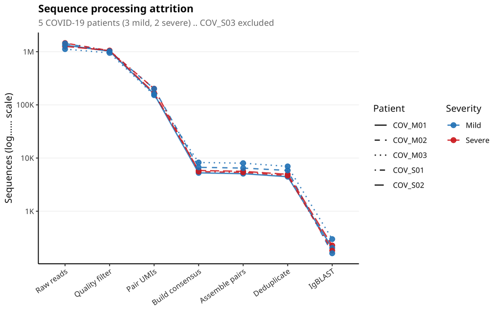

Sequence attrition through the nf-core/airrflow pipeline. Each line represents one patient, coloured by disease severity. The steep drop from ‘Pair UMIs’ to ‘Build consensus’ reflects UMI-based error correction collapsing many raw reads into fewer high-confidence consensus sequences.

Sequence counts at key processing steps.

| Patient | Severity | Raw reads | After QC | Consensus | Assembled | Unique | IgBLAST |
| --- | --- | --- | --- | --- | --- | --- | --- |
| COV_S02 | Severe | 1,259,434 | 1,051,267 | 5,830 | 5,630 | 4,944 | 227 |
| COV_M01 | Mild | 1,329,618 | 1,018,041 | 5,267 | 5,085 | 4,458 | 204 |
| COV_S01 | Severe | 1,453,048 | 1,044,130 | 5,570 | 5,384 | 4,685 | 182 |
| COV_M03 | Mild | 1,118,131 | 949,085 | 8,249 | 8,008 | 6,969 | 299 |
| COV_M02 | Mild | 1,427,691 | 1,026,037 | 6,697 | 6,475 | 5,851 | 162 |

### 3.2 V gene usage

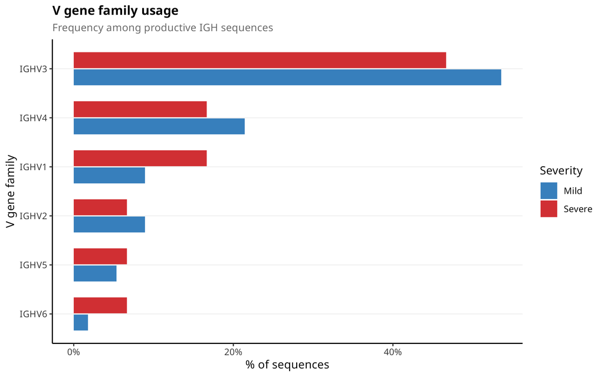

IGHV gene family usage frequencies in mild (blue) and severe (red) COVID-19 patients. Frequencies are pooled across patients within each severity group.

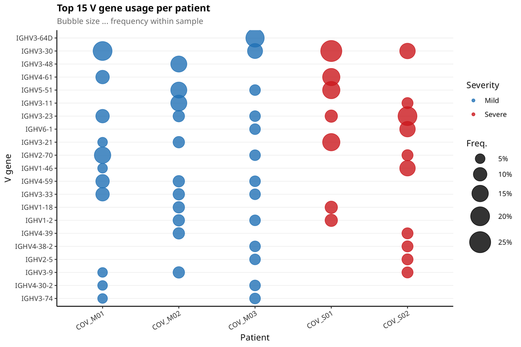

Top 15 IGHV gene usage per patient. Bubble size indicates the frequency of that gene within the patient’s repertoire. Patients are grouped by severity.

IGHV family usage by disease severity.

| Family | Mild (n) | Mild (%) | Severe (n) | Severe (%) |
| --- | --- | --- | --- | --- |
| IGHV3 | 30 | 53.6 | 14 | 46.7 |
| IGHV4 | 12 | 21.4 | 5 | 16.7 |
| IGHV1 | 5 | 8.9 | 5 | 16.7 |
| IGHV2 | 5 | 8.9 | 2 | 6.7 |
| IGHV5 | 3 | 5.4 | 2 | 6.7 |
| IGHV6 | 1 | 1.8 | 2 | 6.7 |

The IGHV3 family dominates in both severity groups, consistent with the known prevalence of IGHV3-53 and IGHV3-66 in COVID-19 anti-spike antibody responses (Galson et al. 2020; Yuan et al. 2020). IGHV4 and IGHV1 contribute measurable fractions in both groups, with minor differences between mild and severe patients — though the small cohort size (n = 5) limits statistical inference.